# INFO 659 Assignment #2 (10 points)

Data Distribution, Clustering and Classification

# Objective

This assignment presents to you a real world problem (credit card defaults) that requires deep understanding of the problem itself, the ability to deal with messiness of real data, and creativity to combine your understanding with machine learning skills to solve the problem.

# Data Source

The data is given in the CSV format, available at (a copy is also available in BBLearn):

https://www.kaggle.com/uciml/default-of-credit-card-clients-dataset

According to the site:

> This dataset contains information on default payments, demographic factors, credit data, history of payment, and bill statements of credit card clients in Taiwan from April 2005 to September 2005.

# R Packages

You may need to install the following packages in the R Console:

```r
install.packages("rpart.plot")
install.packages("ggplot2")
install.packages("e1071")
```

# Problem

Build machine-learning models to predict credit card defaults based on demographic or payment status history data.

# Tasks

Please refer to Chapter 7 and specifically sections 7.1.5 and 7.2.5 on related R code and discussions.

## A. Data Preparation

### A.1. Data Loading and Initial Transformation

Load data and transform the *default.payment.next.month* variable into a **nominal** (factor) variable:

```r
library(ggplot2)
cc <- read.csv("a2/UCI_Credit_Card.csv")
cc$default.payment.next.month <- factor(cc$default.payment.next.month,levels=c(0,1), labels=c("No","Yes"))
```

### A.2. Demographic Variables

Discuss how demographic variables such as education have any impact on payment default.

**SEX, EDUCATION, MARRIAGE, AGE**

- Pick **TWO** variables here, produce a *distribution* for each variable and color code the distribution with *default.payment.next.month* (see code example below).
- **Explain** what you see in the distribution and whether the variable can help predict *default.payment.next.month*.

Here is an example on the *EDUCATION* variable (pay attention to the **plus sign (+)** at the end of each code line to connect them together):

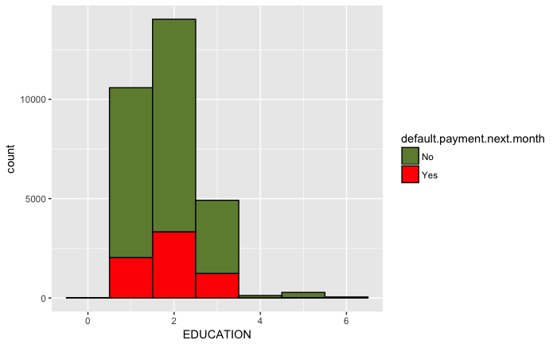

```r
ggplot(cc, aes(x=EDUCATION, fill=default.payment.next.month, color=default.payment.next.month)) +
  geom_histogram(binwidth=1, position="stack") +
  scale_color_manual(values=c("black","black")) +
  scale_fill_manual(values=c("darkolivegreen4", "red"))
```

### A.3. Payment Status Variables

Discuss how payment status data may have an impact on payment default.

**PAY_0, PAY_2, PAY_3, PAY_4, PAY_5, PAY_6**

- Pick **THREE** variables here, produce a *distribution* for each variable and color code the distribution with *default.payment.next.month* (see code example below).
- **Explain** what you see in the distribution and whether the variable can help predict *default.payment.next.month*.

```r
ggplot(cc, aes(x=PAY_0, fill=default.payment.next.month, color=default.payment.next.month)) +
  geom_histogram(binwidth=1, position="stack") +
  scale_color_manual(values=c("black","black")) +
  scale_fill_manual(values=c("darkolivegreen4", "red"))
```

### A.4. Transforming Nominal Variables

Visit the data site at: https://www.kaggle.com/uciml/default-of-credit-card-clients-dataset

- Read the documentation and decide which of the above variables should be nominal (categorical factors);
- Transform related demographic variables into nominal values with proper labels using the factor() function.

For example:

```r
cc$SEX <- factor(cc$SEX,levels=c(1,2), labels=c("Male", "Female"))
```

Use View() function to invoke data viewer and check whether your data have been properly transformed.

### A.5. Selection of Training Data

Please select 5000 random rows as training data:

```r
train <- cc[sample(nrow(cc), 5000), ]
```

Please double check on your training data with nrow(train) and/or View(train).

### A.6. Selection of Testing Data

Please think of any **two random numbers** between 1 and 30,000 (the total number of rows in the original data). Use the two number to pick the **two rows** from data. For example, if you think of 24 and 25358, then using the following code to pick these two rows as test data:

```r
test <- cc[c(24,25358),]      # please do NOT copy the exact numbers here, use your own numbers!!!
test
```

|  | ID | LIMIT_BAL | SEX | EDUCATION | MARRIAGE | AGE | PAY_0 | PAY_2 | PAY_3 | PAY_4 | PAY_5 | PAY_6 | BILL_AMT1 | BILL_AMT2 | BILL_AMT3 | BILL_AMT4 | BILL_AMT5 | BILL_AMT6 | PAY_AMT1 | PAY_AMT2 | PAY_AMT3 | PAY_AMT4 | PAY_AMT5 | PAY_AMT6 | default.payment.next.month |
| --- | --- | --- | --- | --- | --- | --- | --- | --- | --- | --- | --- | --- | --- | --- | --- | --- | --- | --- | --- | --- | --- | --- | --- | --- | --- |
| 24 | 24 | 450000 | NA | NA | NA | 40 | -2 | -2 | -2 | -2 | -2 | -2 | 5512 | 19420 | 1473 | 560 | 0 | 0 | 19428 | 1473 | 560 | 0 | 0 | 1128 | Yes |
| 25358 | 25358 | 180000 | NA | NA | NA | 25 | -1 | 0 | 0 | 0 | 0 | 0 | 62798 | 51923 | 51935 | 47383 | 32876 | 28915 | 1867 | 2501 | 1271 | 926 | 876 | 3004 | No |

[output not shown]